# Session 8.1 KNN: Classifying iPlayer users

> Exercise: How did kNN perform compared to logistic regression?

> Exercise: After the lecture, run knn without scaling and centering the data. How does it perform?

```r
#Predict the class of each user in the test data set
#Recall that the output of 'train' function, in this case 'fit_KNN', automatically keeps the best model
# 'predict' function has many options. Here I am using it to classify new data as 0 or 1 using  'cutoff' value equal to 0.5.
knn_class<-predict(fit_KNN, newdata = combined_test, cutoff = .5 )

###Look at the confusion matrix using 'confusionMatrix' from 'caret' library
confusionMatrix(data = knn_class,reference = combined_test$watched_in_Feb)
```

```
## Confusion Matrix and Statistics
##
##           Reference
## Prediction  No Yes
##        No  703 331
##        Yes 351 953
##
##                Accuracy : 0.7083
##                  95% CI : (0.6894, 0.7267)
##     No Information Rate : 0.5492
##     P-Value [Acc > NIR] : <2e-16
##
##                   Kappa : 0.4099
##
##  Mcnemar's Test P-Value : 0.4669
##
##             Sensitivity : 0.6670
##             Specificity : 0.7422
##          Pos Pred Value : 0.6799
##          Neg Pred Value : 0.7308
##              Prevalence : 0.4508
##          Detection Rate : 0.3007
##    Detection Prevalence : 0.4423
##       Balanced Accuracy : 0.7046
##
##        'Positive' Class : No
##
```

Next I plot the ROC curve for the test data.

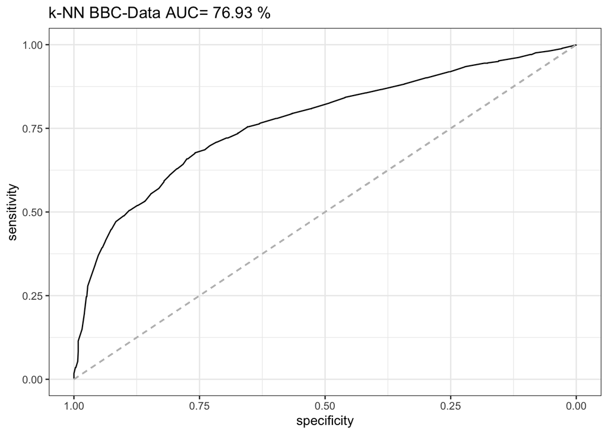

```r
#Load the library pROC to plot ROC curves
suppressMessages(library(pROC))

# I use 'predict' function to estimate probabilities. The result has two columns; first the probabilty of being class 0 and second # for being 1. So I take the second column

knn_prediction_testing<-predict(fit_KNN, newdata = combined_test,type = "prob")[,2]

# Let's find the ROC values using 'roc' function from pROC.
ROC_knn <- roc(combined_test$watched_in_Feb, knn_prediction_testing)
# Let's find AUC using the 'auc' function and round it for ease of notation.
AUC_knn<-round(auc(ROC_knn)*100, digits=2)
# Finally let's plot the ROC curve using
ggroc(ROC_knn) + theme_bw()+ggtitle(paste("k-NN BBC-Data AUC=",AUC_knn,"%"))+geom_segment(aes(x = 1, xend = 0, y = 0, yend = 1), color="grey", linetype="dashed")
```

> Exercise: How does K-NN perform relative to the basic logistic regression model? Plot two ROC charts to compare (something you have done when you compared different logistic regression methods).

## 5.1 Other libraries in R (Side note)

We can also use the ‘class’ package and ‘knn’ function, here is the link https://www.rdocumentation.org/packages/class/versions/7.3-15/topics/knn

Although it may seem that this function has a simpler syntax, it requires a lot of pre and post processing to train the K-NN algorithm and it does not provide an easy way of tuning the “k” parameter. Hence I prefer using the `caret` library.

Another library that implement `knn` with weighted distances is the `kknn` function. You can use this function with `caret` as well. Here is the link for this function. https://www.rdocumentation.org/packages/kknn/versions/1.3.1/topics/kknn

# 6 A simple ensemble method

There are many ways to merge classification algorithms to improve their performance. We will see a variety of ways to do this this and next week.

A simple way to “ensemble” different machnine learning algorithms is to use the predictions of a machone Learning algorithms as independent variable in another. I demonstrate this below by adding the results of k-NN to independent variables in logistic regression.

> Exercise: How can we use the results of clustering in a similar ensemble method?

```r
knn_prediction_training<-predict(fit_KNN, newdata = combined_train,type = "prob")[,2]
#I set the number of clusters equal to 4
combined_train<-combined_train%>%mutate(knn_Predict=knn_prediction_training)
combined_test<-combined_test%>%mutate(knn_Predict=knn_prediction_testing)

glimpse(combined_test)
```

```
## Rows: 2,338
## Columns: 23
## $ weekday             <dbl> 1.0000000, 1.0000000, 0.6666667, 0.7500000, 0.0000…
## $ weekend             <dbl> 0.0000000, 0.0000000, 0.3333333, 0.2500000, 1.0000…
## $ Afternoon           <dbl> 0.0000000, 0.0000000, 0.0000000, 0.1500000, 0.0000…
## $ Day                 <dbl> 1.000, 0.000, 0.000, 0.450, 0.000, 0.000, 1.000, 0…
## $ Evening             <dbl> 0.0000000, 1.0000000, 1.0000000, 0.4000000, 1.0000…
## $ Night               <dbl> 0.0000000, 0.0000000, 0.0000000, 0.0000000, 0.0000…
## $ Children            <dbl> 0, 0, 0, 0, 0, 0, 0, 0, 0, 0, 0, 0, 0, 0, 0, 0, 0,…
## $ Comedy              <dbl> 0.00000, 0.00000, 0.00000, 0.00000, 0.00000, 0.000…
## $ Drama               <dbl> 0.00000, 0.00000, 33.33333, 0.00000, 100.00000, 50…
## $ Entertainment       <dbl> 0.00000, 0.00000, 0.00000, 10.00000, 0.00000, 0.00…
## $ Factual             <dbl> 0.0, 0.0, 0.0, 30.0, 0.0, 0.0, 0.0, 0.0, 0.0, 0.0,…
## $ Learning            <dbl> 0, 0, 0, 0, 0, 0, 0, 0, 0, 0, 0, 0, 0, 0, 0, 0, 0,…
## $ Music               <dbl> 0.00000, 0.00000, 0.00000, 0.00000, 0.00000, 0.000…
## $ News                <dbl> 100.00000, 0.00000, 33.33333, 50.00000, 0.00000, 0…
## $ NoGenre             <dbl> 0, 0, 0, 0, 0, 0, 0, 100, 0, 0, 0, 0, 0, 0, 0, 0, …
## $ RelEthics           <dbl> 0, 0, 0, 0, 0, 0, 0, 0, 0, 0, 0, 0, 0, 0, 0, 0, 0,…
## $ Sport               <dbl> 0, 100, 0, 5, 0, 50, 100, 0, 0, 0, 0, 0, 25, 0, 0,…
## $ Weather             <dbl> 0.00000, 0.00000, 33.33333, 5.00000, 0.00000, 0.00…
## $ per_al_Watched      <dbl> 0.00000, 0.00000, 0.00000, 35.00000, 0.00000, 0.00…
## $ watched_in_Feb      <fct> No, No, Yes, Yes, No, No, Yes, Yes, No, No, No, Ye…
## $ log_total_Time      <dbl> 0.6239579, 1.0299765, 1.4167751, 6.1004420, 2.6661…
## $ log_number_of_shows <dbl> 0.6931472, 0.0000000, 1.0986123, 2.9957323, 0.0000…
## $ knn_Predict         <dbl> 0.4714286, 0.3714286, 0.5714286, 0.8000000, 0.3714…
```

```r
#train a logistic regression model
bbc_logreg_Fit_ens<-glm(formula=watched_in_Feb  ~ Day+log_total_Time+log_number_of_shows+knn_Predict ,
                    data = combined_train,family = "binomial")
summary(bbc_logreg_Fit_ens)
```

```
##
## Call:
## glm(formula = watched_in_Feb ~ Day + log_total_Time + log_number_of_shows +
##     knn_Predict, family = "binomial", data = combined_train)
##
## Deviance Residuals:
##     Min       1Q   Median       3Q      Max
## -2.4624  -0.8891   0.4118   0.8692   1.9041
##
## Coefficients:
##                     Estimate Std. Error z value Pr(>|z|)
## (Intercept)         -2.07250    0.10748 -19.283  < 2e-16 ***
## Day                  0.11709    0.07003   1.672   0.0945 .
## log_total_Time       0.06240    0.01954   3.194   0.0014 **
## log_number_of_shows  0.40744    0.05012   8.130  4.3e-16 ***
## knn_Predict          2.75304    0.26795  10.275  < 2e-16 ***
## ---
## Signif. codes:  0 '***' 0.001 '**' 0.01 '*' 0.05 '.' 0.1 ' ' 1
##
## (Dispersion parameter for binomial family taken to be 1)
##
##     Null deviance: 9660.4  on 7012  degrees of freedom
## Residual deviance: 7789.1  on 7008  degrees of freedom
## AIC: 7799.1
##
## Number of Fisher Scoring iterations: 4
```

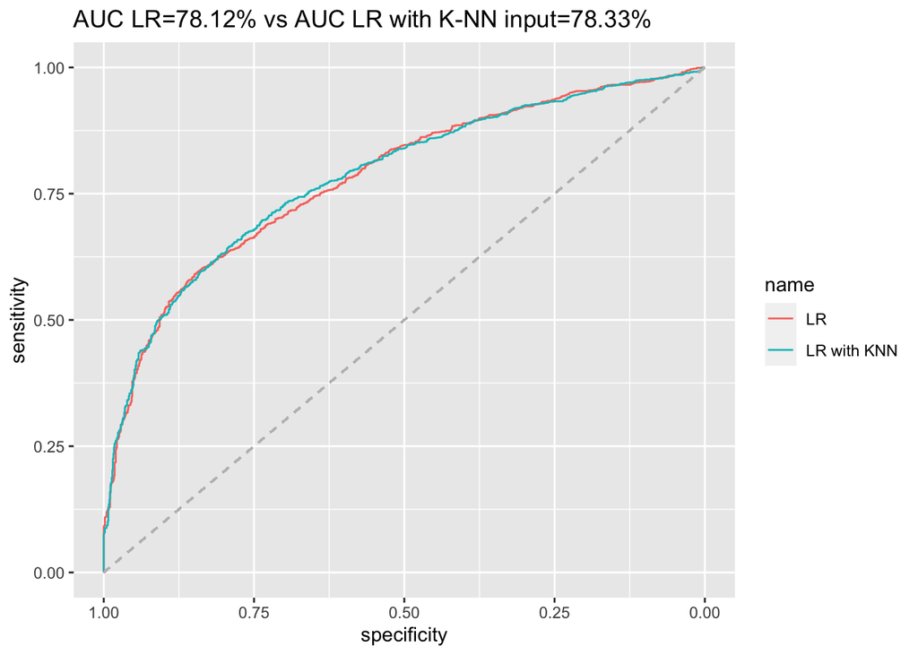

```r
# Next I predict the probabilities and then plot the ROC curve for the testing data.
knn_prediction_testing<- bbc_logreg_Fit_ens%>%predict(combined_test,type = "response")


library(pROC)
ROC_lr2 <- roc(combined_test$watched_in_Feb, knn_prediction_testing)
# Calculate the area under the curve (AUC)
AUC_lr2<-round(auc(ROC_lr2)*100, digits=2)
# Plot the ROC curve
g2 <- ggroc(list("LR"=ROC_lr,"LR with KNN"=ROC_lr2))
g2+ggtitle(paste("AUC LR=",AUC_lr,"%"," vs AUC LR with K-NN input=",AUC_lr2,"%",sep="" ))+geom_segment(aes(x = 1, xend = 0, y = 0, yend = 1), color="grey", linetype="dashed")
```